# Hotel business

# Data description

The full description and specification of this data can be found in “Hotel booking demand datasets,” by Nuno Antonio, Ana de Almeida, and Luis Nunes. Abstract:

> This data article describes two datasets with hotel demand data. One of the hotels (H1) is a resort hotel and the other is a city hotel (H2). Both datasets share the same structure, with 31 variables describing the 40,060 observations of H1 and 79,330 observations of H2. Each observation represents a hotel booking. Both datasets comprehend bookings due to arrive between the 1st of July of 2015 and the 31st of August 2017, including bookings that effectively arrived and bookings that were canceled. Since this is hotel real data, all data elements pertaining hotel or costumer identiﬁcation were deleted. Due to the scarcity of real business data for scientiﬁc and educational purposes, these datasets can have an important role for research and education in revenue management, machine learning, or data mining, as well as in other ﬁelds.

The data is open access. The data was cleaned for Tidy Tuesday and is available on the [TidyTuesday](https://github.com/rfordatascience/tidytuesday/blob/master/data/2020/2020-02-11/readme.md) github page for this week. This page includes the cleaning script used to generate the data I am using.

Some key facts:

- Both hotels are in Portugal
- The data was acquired through the hotels’ property management system (PMS) databases.
- Some variables were engineered from other variables from different database tables.
- The data point time for each observation was defined as the day prior to each booking’s arrival.
- Hotel H1 is from the resort region fo Algarve
- Hotel H2 is at the city of Lisbon

Some suggested uses:

- Perform research in: booking cancellation prediction, customer segmentation, customer satiation, seasonality, etc.
- Machine learning applications such as segmentation and classification problems.

The data is minimally cleaned by the Tidy folks. Names are the biggest change.

# A First Look

Let’s get the data.

```r
hotels <- readr::read_csv('https://raw.githubusercontent.com/rfordatascience/tidytuesday/master/data/2020/2020-02-11/hotels.csv')
save(hotels, file = 'data/hotels.RData')
```

We can look at the data with the `skimr` package.

```r
skimr::skim(hotels)
```

```
-- Data Summary ------------------------
                           Values
Name                       hotels
Number of rows             119390
Number of columns          32
_______________________
Column type frequency:
  character                13
  Date                     1
  numeric                  18
________________________
Group variables            None

-- Variable type: character -------------------------------------------------
# A tibble: 13 x 8
   skim_variable        n_missing complete_rate   min   max empty n_unique
 * <chr>                    <int>         <dbl> <int> <int> <int>    <int>
 1 hotel                        0             1    10    12     0        2
 2 arrival_date_month           0             1     3     9     0       12
 3 meal                         0             1     2     9     0        5
 4 country                      0             1     2     4     0      178
 5 market_segment               0             1     6    13     0        8
 6 distribution_channel         0             1     3     9     0        5
 7 reserved_room_type           0             1     1     1     0       10
 8 assigned_room_type           0             1     1     1     0       12
 9 deposit_type                 0             1    10    10     0        3
10 agent                        0             1     1     4     0      334
11 company                      0             1     1     4     0      353
12 customer_type                0             1     5    15     0        4
13 reservation_status           0             1     7     9     0        3
   whitespace
 *      <int>
 1          0
 2          0
 3          0
 4          0
 5          0
 6          0
 7          0
 8          0
```

[output cut: 42 more lines]

```
 4    1      16     28      38    53 ▅▇▇▇▅
 5    1       8     16      23    31 ▇▇▇▇▆
 6    0       0      1       2    19 ▇▁▁▁▁
 7    0       1      2       3    50 ▇▁▁▁▁
 8    0       2      2       2    55 ▇▁▁▁▁
 9    0       0      0       0    10 ▇▁▁▁▁
10    0       0      0       0    10 ▇▁▁▁▁
11    0       0      0       0     1 ▇▁▁▁▁
12    0       0      0       0    26 ▇▁▁▁▁
13    0       0      0       0    72 ▇▁▁▁▁
14    0       0      0       0    21 ▇▁▁▁▁
15    0       0      0       0   391 ▇▁▁▁▁
16   -6.38   69.3   94.6   126  5400 ▇▁▁▁▁
17    0       0      0       0     8 ▇▁▁▁▁
18    0       0      0       1     5 ▇▁▁▁▁
```

I’ll leave this here for reference. The unit of observation is a hotel booking, but I don’t have an ID variable besides row number. What variables would define one? `hotel` and `reservation_status_date` are inadequate, but the data does break along this line at least. After this, you need to simply trust that each observation is a different booking. Maybe I should make a variable to distinguish the identical bookings for each reservation date.

For visualization I might want to summarize this data along some variable. For this, I will probably use hotel, booking date, plus a variable of interest (company, customer_type, is_repeated_guest, etc.).

# Ideas

What’s my question? The data lends itself to cancellations, and these are easy to burn through without much data rearranging. I’ll start by answering “who cancels the most?” for several demographics:

- Customer type
- Repeated guests (note: only 3% of guests are repeated guests; data will be sporadic)
- Distribution channel (do bookings through travel agents cancel less often? Does this earn them a discount?)
- Lead time
- Required car parking spaces. (Proxy for something? Maybe only for group size. Probably trash.)
- Total of special requests
- Deposit type (viz. whether a deposit was made)
- Country
- Number of children
- Season, month, day of the week of arrival
- Average daily rate (ADR)

Time-variant factors

- Year

The dependent variable is `is_canceled`.

An important variable will be arrival date, which is currently scattered across several variables. Let me bring them together.

```r
hotels <- hotels %>%
  mutate(
    arrival_date = glue::glue("{arrival_date_day_of_month}_{arrival_date_month}_{arrival_date_year}"),
    arrival_date = parse_date(arrival_date, format = "%d_%B_%Y")
  )
```

# Tables

Since the outcome variable is binary, these questions lend themselves to tables more than graphics. If I see an interesting trend, maybe a more complex graphic will follow. For the tables, I’m going to use the `janitor` package’s function `tabyl`.

### Customer type

There are four categories of customer (quoted from paper):

1. Contract: when the booking has an allotment or other type of contract associated to it.
2. Group: When the booking is associated to a group.
3. Transient: When the booking is not part of a group or contract, and is not associated to other transient booking.
4. Transient-party: When the booking is transient, but is associated to at least other transient booking.

```r
hotels %>%
  tabyl(customer_type)
```

```
   customer_type     n     percent
        Contract  4076 0.034140213
           Group   577 0.004832901
       Transient 89613 0.750590502
 Transient-Party 25124 0.210436385
```

Most bookings are transient. Group bookings are very rare, but transient parties are very common. If I include all transient-party observations, will I be (at least) double-counting? I have no way of knowing, so I will include all observations.

```r
hotels %>%
  tabyl(customer_type, is_canceled) %>%
  adorn_percentages('row') %>%
  adorn_pct_formatting()
```

```
   customer_type     0     1
        Contract 69.0% 31.0%
           Group 89.8% 10.2%
       Transient 59.3% 40.7%
 Transient-Party 74.6% 25.4%
```

Let me write a quick function for using `tabyl` in this manner.

```r
p <- function(tabyl) {
  tabyl %>%
    adorn_percentages('row') %>%
    adorn_pct_formatting()
}

hotels %>%
  tabyl(customer_type, is_canceled) %>%
  p()
```

```
   customer_type     0     1
        Contract 69.0% 31.0%
           Group 89.8% 10.2%
       Transient 59.3% 40.7%
 Transient-Party 74.6% 25.4%
```

### Repeated guests

Has the guest stayed at that hotel before? There is no indication of how long ago they might’ve stayed at the hotel, so this may or may not be reliable.

```r
hotels %>%
  tabyl(is_repeated_guest) %>%
  adorn_pct_formatting()
```

```
 is_repeated_guest      n percent
                 0 115580   96.8%
                 1   3810    3.2%
```

As I said above, most guests are not repeat guests.

```r
hotels %>%
  tabyl(is_repeated_guest, is_canceled) %>%
  p()
```

```
 is_repeated_guest     0     1
                 0 62.2% 37.8%
                 1 85.5% 14.5%
```

A weakness of `tabyl`s is that they have very poor labeling. Anyway, repeated guests are in fact much less likely to cancel.

### Distribution channel and dates observed

The possible options are “TA” for travel agent, or “TO” for tour operator. What about those who don’t belong in either?

```r
hotels %>%
  tabyl(distribution_channel) %>%
  adorn_pct_formatting()
```

```
 distribution_channel     n percent
            Corporate  6677    5.6%
               Direct 14645   12.3%
                  GDS   193    0.2%
                TA/TO 97870   82.0%
            Undefined     5    0.0%
```

An unusual number of guests book through travel agents or tour operators. I wonder if websites count as travel agents. Direct is probably booking directly with the hotel, I guess by their website or by calling ahead. Corporate is obvious enough; GDS is nonsense to me, but it’s a very small part of the population. If TA/TO includes websites, you might see their popularity increase over time. Let me try to look at that.

First, a look at the dates. There are three years observed (2015-2017), and most of the data comes from the middle year, 2016.

```r
hotels %>%
  tabyl(arrival_date_year)
```

```
 arrival_date_year     n   percent
              2015 21996 0.1842365
              2016 56707 0.4749728
              2017 40687 0.3407907
```

It turns out, this is because there are several months with no observations in 2015 and 2017. It will be difficult to learn much about the seasonality of the data when I only have one full year.

```r
hotels %>%
  tabyl(arrival_date_month, arrival_date_year)
```

```
 arrival_date_month 2015 2016 2017
              April    0 5428 5661
             August 3889 5063 4925
           December 2920 3860    0
           February    0 3891 4177
            January    0 2248 3681
               July 2776 4572 5313
               June    0 5292 5647
              March    0 4824 4970
                May    0 5478 6313
           November 2340 4454    0
            October 4957 6203    0
          September 5114 5394    0
```

It still might be possible to look at the changes in channel over time, but the picture will be somewhat incomplete. What if some months have higher rates of booking directly? I will compare similar months across the years. Amazingly, there are only two months observed in all three years: August and July. Fortunately, every month is observed in at least two years.

```r
hotels %>%
  tabyl(arrival_date_month, arrival_date_year, hotel)
```

```
$`City Hotel`
 arrival_date_month 2015 2016 2017
              April    0 3561 3919
             August 2480 3378 3125
           December 1654 2478    0
           February    0 2371 2594
            January    0 1364 2372
               July 1398 3131 3559
               June    0 3923 3971
              March    0 3046 3412
                May    0 3676 4556
           November 1235 3122    0
            October 3386 4219    0
          September 3529 3871    0

$`Resort Hotel`
 arrival_date_month 2015 2016 2017
              April    0 1867 1742
             August 1409 1685 1800
           December 1266 1382    0
           February    0 1520 1583
            January    0  884 1309
               July 1378 1441 1754
               June    0 1369 1676
              March    0 1778 1558
                May    0 1802 1757
           November 1105 1332    0
            October 1571 1984    0
          September 1585 1523    0
```

The hotels are always observed in the same months. I don’t know how to fix the alphabetical sorting, it shouldn’t do that, but the months might be character vectors so then it would make sense. I’m not worrying about it.

Coming back to the question at hand, let’s look at monthly trends in the ratio of distribution channel options over time.

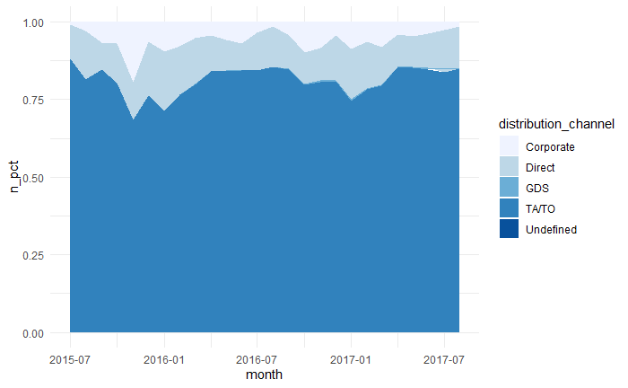

```r
hotels_month_dist <- hotels %>%
  mutate(
    month = glue::glue("{arrival_date_month}_{arrival_date_year}"),
    month = parse_date(month, format = "%B_%Y")
  ) %>%
  group_by(month, distribution_channel) %>%
  summarize(n = n()) %>%
  group_by(month) %>%
  mutate(
    n_sum = sum(n, na.rm = TRUE),
    n_pct = n / n_sum
  )

hotels_month_dist %>%
  ggplot() +
  geom_area(
    aes(x = month, y = n_pct,
        group = distribution_channel,
        fill = distribution_channel)
  ) +
  scale_fill_brewer() +
  theme_minimal()
```

```r
hotels %>%
  tabyl(distribution_channel, is_canceled) %>%
  p()
```

```
 distribution_channel     0     1
            Corporate 77.9% 22.1%
               Direct 82.5% 17.5%
                  GDS 80.8% 19.2%
                TA/TO 59.0% 41.0%
            Undefined 20.0% 80.0%
```

There is another variable, `market_segment`, which might be more useful for analysis.

```r
hotels %>%
  tabyl(market_segment) %>%
  adorn_pct_formatting()
```

```
 market_segment     n percent
       Aviation   237    0.2%
  Complementary   743    0.6%
      Corporate  5295    4.4%
         Direct 12606   10.6%
         Groups 19811   16.6%
  Offline TA/TO 24219   20.3%
      Online TA 56477   47.3%
      Undefined     2    0.0%
```

This confirms that online travel agents make almost half of all bookings. The variables `market_segment` and `distribution_channel` are not always comparable.

```r
hotels %>%
  tabyl(market_segment, distribution_channel)
```

```
 market_segment Corporate Direct GDS TA/TO Undefined
       Aviation       227      0   0    10         0
  Complementary        89    576   0    78         0
      Corporate      4788    172   0   335         0
         Direct        90  12276   1   237         2
         Groups      1228   1472   0 17111         0
  Offline TA/TO       212     16  45 23946         0
      Online TA        43    133 147 56153         1
      Undefined         0      0   0     0         2
```

Regardless, let’s look at the cancellations of each `market_segment` type.

```r
hotels %>%
  tabyl(market_segment, is_canceled) %>%
  p()
```

```
 market_segment     0      1
       Aviation 78.1%  21.9%
  Complementary 86.9%  13.1%
      Corporate 81.3%  18.7%
         Direct 84.7%  15.3%
         Groups 38.9%  61.1%
  Offline TA/TO 65.7%  34.3%
      Online TA 63.3%  36.7%
      Undefined  0.0% 100.0%
```

### Lead time

Lead time is the “number of days that elapsed between the entering date of the booking into the PMS and the arrival date,” (Antonio, et al. 2019).

The average booker makes the reservation around 70 days out, with some booking as many as 2 years in advance.

```r
summary(hotels$lead_time)
```

```
   Min. 1st Qu.  Median    Mean 3rd Qu.    Max.
      0      18      69     104     160     737
```

How does this break down by reservation type? There is substantial heterogeneity between different groups. Transient bookers fall in the middle, with contracts being made the furthest in advance and ‘groups’ being made less than two weeks away on average. This might not be accurate, as group bookings are very uncommon.

```r
hotels %>%
  group_by(customer_type) %>%
  summarize(median_lead = median(lead_time, na.rm = TRUE))
```

| customer_type | median_lead |
| --- | --- |
| Contract | 114 |
| Group | 12 |
| Transient | 61 |
| Transient-Party | 102 |

Be aware that transients have shorter lead times on average and are more likely to cancel. With that in mind, let’s see if a higher lead time is correlated with a higher cancellation rate. We can look at a simple correlation.

```r
cor(x = hotels$lead_time, y = hotels$is_canceled)
```

```
[1] 0.2931234
```

The direction seems to be positive. Let’s look at a graphic. I can get an accurate picture if I summarize by `lead_time`, but the result is noisy.

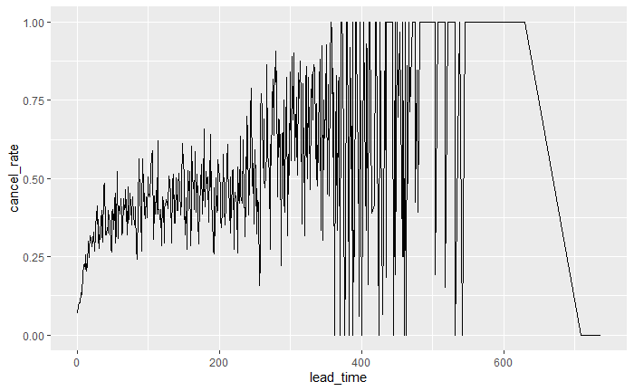

```r
hotels %>%
  group_by(lead_time) %>%
  summarize(cancel_rate = mean(is_canceled, na.rm = TRUE)) %>%
  ggplot() +
  geom_line(aes(x = lead_time, y = cancel_rate))
```

Instead, I will bucket and restrict the data to lead times of up to one year. The upward trend is clear: as lead time increases, the likelihood of canceling increases. This makes a lot of sense. If you book a trip a week away, what are the odds you won’t be able to make it? Slim. If you book a trip a year away, what are the odds you forget about it, or something comes up that you can’t avoid, or the money just isn’t there anymore? People have a weak ability to anticipate future events and situations farther out than a few weeks.

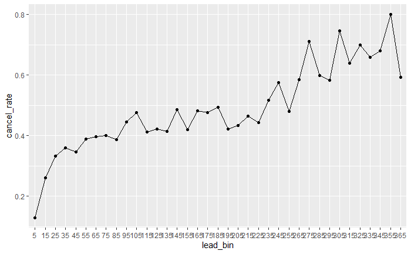

```r
hotels %>%
  filter(lead_time <= 365) %>%
  mutate(
    lead_bin = cut(lead_time, breaks = seq(0,370, 10), labels = as.character(seq(5,365,10))),
    lead_bin = forcats::fct_explicit_na(lead_bin)
  ) %>%
  group_by(lead_bin) %>%
  summarize(cancel_rate = mean(is_canceled, na.rm = TRUE)) %>%
  filter(lead_bin != "(Missing)") %>%
  ggplot() +
  geom_point(aes(x = lead_bin, y = cancel_rate)) +
  geom_line(aes(x = as.numeric(lead_bin), y = cancel_rate))
```

This graphic might be worth publishing. It seems to respond to people who say that you get the best prices when you book further in advance. This question is actually pretty complicated. Consider the optimization problem facing the hotel owners. Some important factors:

1. Time-value of money (applies to those who put down a deposit)
2. Likelihood that the individual/group will cancel
3. Likelihood that another individual/group will book in place of the lost booking

To know more about point three, you need to know *how long it takes you to cancel*. If I make a reservation a year in advance, I’ve got around a 60-70% chance of canceling. When will I do it? Will there be enough time for another booking to take the lost one’s place? Do most people wait until the last second to cancel, even when they booked a year in advance? In fact, the data is included in this dataset. There are two types of date variables: `arrival_date` variables and the variable `reservation_status_date`. From these I can derive the cancellation lead time.

```r
hotels <- hotels %>%
  mutate(
    cancel_lead_time = case_when(
      is_canceled == 1 ~ arrival_date - reservation_status_date,
      is_canceled == 0 ~ 0
    )
    )
```

Note: `reservation_status_date` is the date of last update. This means that if you check out after your arrival date, `reservation_status_date` will list your checkout date. Hence, the conditional in the above definition.

Let’s look at how cancellation lead time and lead time vary with each other.

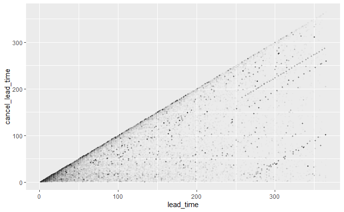

```r
hotels %>%
  filter(lead_time <= 365, cancel_lead_time > 0) %>%
  ggplot() +
  geom_point(aes(x = lead_time, y = cancel_lead_time),
                 alpha = 0.01, shape = 20)
```

The line of slope = 1 is fairly strong, meaning many people cancel the same day they book. But this decreases as the lead-time increases. That’s partially because there are fewer observations as lead-time increases, though. This graphic is showing two things at once, which isn’t as effective as it could be. Instead, I would like a new way of seeing how lead time and cancellation lead time are related. For this, let me look average cancellation lead times for each lead time.

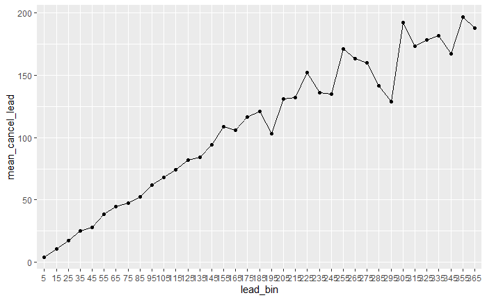

```r
hotels %>%
  filter(lead_time <= 365, cancel_lead_time > 0) %>%
  mutate(
    lead_bin = cut(lead_time, breaks = seq(0,370, 10), labels = as.character(seq(5,365,10))),
    lead_bin = forcats::fct_explicit_na(lead_bin)
  ) %>%
  group_by(lead_bin) %>%
  summarize(mean_cancel_lead = mean(cancel_lead_time, na.rm = TRUE)) %>%
  ggplot() +
  geom_point(aes(x = lead_bin, y = mean_cancel_lead)) +
  geom_line(aes(x = as.numeric(lead_bin), y = mean_cancel_lead))
```

No great changes beyond the expected variation. What about plotting the cancellation lead time as a fraction of the lead time?

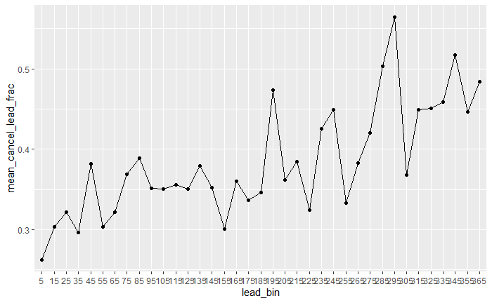

```r
hotels %>%
  filter(lead_time <= 365, cancel_lead_time > 0) %>%
  mutate(
    cancel_lead_time_frac = (lead_time - cancel_lead_time) / lead_time,
    lead_bin = cut(lead_time, breaks = seq(0,370, 10), labels = as.character(seq(5,365,10))),
    lead_bin = forcats::fct_explicit_na(lead_bin)
  ) %>%
  group_by(lead_bin) %>%
  summarize(mean_cancel_lead_frac = mean(cancel_lead_time_frac, na.rm = TRUE)) %>%
  ggplot() +
  geom_point(aes(x = lead_bin, y = mean_cancel_lead_frac)) +
  geom_line(aes(x = as.numeric(lead_bin), y = mean_cancel_lead_frac))
```

Generally, those who book further in advance give earlier notice that they are canceling. This is more try when you get close to 365 days in advance.

### Total parking spaces requested

I chose this variable because there seem to be specialized cases when you need extra parking spaces, but I haven’t yet thought of them all. Groups, you would imagine, request many parking spaces.

```r
hotels %>%
  tabyl(required_car_parking_spaces, customer_type) %>%
  adorn_percentages('col') %>%
  adorn_pct_formatting()
```

```
 required_car_parking_spaces Contract Group Transient Transient-Party
                           0    96.7% 91.2%     92.8%           96.8%
                           1     3.3%  8.8%      7.1%            3.2%
                           2     0.0%  0.0%      0.0%            0.0%
                           3     0.0%  0.0%      0.0%            0.0%
                           8     0.0%  0.0%      0.0%            0.0%
```

It is interesting to note that the vast majority of bookers do not require a parking space. I wonder what causes someone to request one?

### Total of special requests

A customer will make a special request when they want a high floor, a twin bed, etc. This variable, `total_of_special_requests`, records the number of special requests made. 59% made no requests, so a fair number of people made one or more requests.

```r
hotels %>%
  tabyl(total_of_special_requests) %>%
  adorn_pct_formatting()
```

```
 total_of_special_requests     n percent
                         0 70318   58.9%
                         1 33226   27.8%
                         2 12969   10.9%
                         3  2497    2.1%
                         4   340    0.3%
                         5    40    0.0%
```

How do cancellation rates vary with the number of special requests? In general, the number of special requests you make is inversely related to the likelihood that you cancel: more requests, a smaller chance that you will cancel. It’s unclear why this would be the case. Maybe you care more about your booking when you make a special request, so you’re more likely to follow-through. Certainly, no one who’s apathetic about their booking is going to make a lot of special requests about it.

```r
hotels %>%
  tabyl(total_of_special_requests, is_canceled) %>%
  p()
```

```
 total_of_special_requests     0     1
                         0 52.3% 47.7%
                         1 78.0% 22.0%
                         2 77.9% 22.1%
                         3 82.1% 17.9%
                         4 89.4% 10.6%
                         5 95.0%  5.0%
```

### Deposit type

This is a classic tool for incentivizing bookers to follow-through. There are three types of deposit:

- No deposit
- Non-refund
- Refundable

These aren’t so intuitive. ‘No deposit’ is what is says, but the definitions of ‘non-refund’ and ‘refundable’ are indirect. A deposit is marked as ‘non-refund’ if the deposit was equal to or greater than the cost of the stay. A deposit is marked as ‘refund’ if it is less than the cost of the stay. In almost all cases values are either ‘No deposit’ or ‘Non-refund’. Most bookers don’t have deposits. I suspect a certain type of customer (probably booked through agency or company) would be required to make a deposit.

```r
hotels %>%
  tabyl(deposit_type) %>%
  adorn_pct_formatting()
```

```
 deposit_type      n percent
   No Deposit 104641   87.6%
   Non Refund  14587   12.2%
   Refundable    162    0.1%
```

Before I delve into this variable too deeply, let me look at cancellation rates. Deposits are an extremely ineffective tool for preventing cancellations: 99.4% of those who paid a non-refundable deposit canceled. This is so impressive that I’m skeptical it could be true. Perhaps, if someone pays in full ahead of time, it doesn’t matter whether they show up or not – they are simply listed as canceled. Some forensic work would need to be done to figure out why this is the case, and I don’t care enough.

```r
hotels %>%
  tabyl(deposit_type, is_canceled) %>%
  p()
```

```
 deposit_type     0     1
   No Deposit 71.6% 28.4%
   Non Refund  0.6% 99.4%
   Refundable 77.8% 22.2%
```

I’m going to do some quick cross-sections to see who has which type of deposit.

```r
hotels %>%
  tabyl(deposit_type, customer_type) %>%
  adorn_percentages('col') %>%
  adorn_pct_formatting()
```

```
 deposit_type Contract Group Transient Transient-Party
   No Deposit    86.6% 98.6%     85.6%           95.0%
   Non Refund    13.3%  0.0%     14.4%            4.5%
   Refundable     0.0%  1.4%      0.0%            0.5%
```

The only sure pattern here is that groups do not put down full deposits.

```r
hotels %>%
  tabyl(deposit_type, market_segment) %>%
  adorn_percentages('col') %>%
  adorn_pct_formatting()
```

```
 deposit_type Aviation Complementary Corporate Direct Groups Offline TA/TO
   No Deposit   100.0%        100.0%     93.6%  99.8%  53.0%         79.3%
   Non Refund     0.0%          0.0%      6.3%   0.2%  46.3%         20.7%
   Refundable     0.0%          0.0%      0.1%   0.0%   0.7%          0.0%
 Online TA Undefined
     99.9%    100.0%
      0.1%      0.0%
      0.0%      0.0%
```

This provides an interesting look at the booking process. Of course, there would normally be someone I could ask about this to confirm what I’m trying to deduce. Anyway, market segments that do not put down deposits include: aviation (through an airline?), complementary, direct bookings, and online travel agents. Market segments that frequently put down deposits include: corporate bookings, groups (this contradicts the above table), and offline travel agents/organizations.

The quality of the variables `market_segment`, `customer_type`, and `distribution_channel` is unclear. How do they relate to each other? How are they defined and entered?

### Country

Some countries might tend to be flighty – let’s find out. There are many countries, so I will limit my analysis to the 20 most frequent visitors. This retains around 93% of the observations while eliminating most of the countries in the list.

```r
country_list <- hotels %>%
  group_by(country) %>%
  summarize(n = n()) %>%
  arrange(desc(n)) %>%
  head(n = 20) %>%
  pull(country)

h_countries <- hotels %>%
  filter(country %in% country_list)
```

Which countries cancel the most? First place is Portugal, which makes sense: if you aren’t traveling, you are more comfortable canceling a reservation. But this idea falls apart with the next few countries: China, Russia, Brazil, Italy. But it could be noted that Portugal’s cancellation rate is 10 percentage points higher than that of the runner up, China.

```r
h_countries %>%
  tabyl(country, is_canceled) %>%
  p() %>%
  arrange(desc(`1`))
```

| country | 0 | 1 |
| --- | --- | --- |
| PRT | 43.4% | 56.6% |
| CHN | 53.8% | 46.2% |
| RUS | 62.2% | 37.8% |
| BRA | 62.7% | 37.3% |
| ITA | 64.6% | 35.4% |
| NOR | 70.2% | 29.8% |
| ESP | 74.6% | 25.4% |
| ISR | 74.7% | 25.3% |
| CHE | 75.3% | 24.7% |
| IRL | 75.3% | 24.7% |

[output cut: 10 more lines]

On the other end of the spectrum, the foreigners most likely to show up are Germany, Austria, the Netherlands, and France. It might be interesting to plot the cancellation rate on a map. I’ll table it for now.

### Number of Children

More children, more spontaneous reasons you can’t go on vacation anymore, right? Let’s get into it. 93% of the individuals had no children; an almost equal number had either one or two (4% and 3%, respectively). Any more than two was rare.

```r
hotels %>%
  tabyl(children) %>%
  adorn_pct_formatting()
```

```
 children      n percent valid_percent
        0 110796   92.8%         92.8%
        1   4861    4.1%          4.1%
        2   3652    3.1%          3.1%
        3     76    0.1%          0.1%
       10      1    0.0%          0.0%
       NA      4    0.0%             -
```

How is your number of children related to your cancellation rate? The evidence is small, but it seems that having two children is a recipe for disaster. Having three children, on the other hand, makes your booking practically a guarantee. This is not where any answers are, I think.

```r
hotels %>%
  tabyl(children, is_canceled) %>%
  p()
```

```
 children     0      1
        0 62.9%  37.1%
        1 67.8%  32.2%
        2 57.8%  42.2%
        3 77.6%  22.4%
       10  0.0% 100.0%
       NA  0.0% 100.0%
```

### Season, month, day of the week of arrival

I’ll need a summary dataset for each unit of time.

```r
hotels_month <- hotels %>%
  mutate(
    month = month(arrival_date)
  ) %>%
  group_by(month) %>%
  summarize(
    n = n(),
    cancel_rate = mean(is_canceled, na.rm = TRUE)
  ) %>%
  ungroup() %>%
  mutate(
    n_sum = sum(n, na.rm = TRUE),
    n_pct = n / n_sum
  )

hotels_season <- hotels %>%
  mutate(
    month = month(arrival_date),
    season = case_when(
      month %in% c(1,2,12) ~ 'winter',
      month %in% c(3,4,5) ~ 'spring',
      month %in% c(6,7,8) ~ 'summer',
      month %in% c(9,10,11) ~ 'fall'
    )
  ) %>%
  group_by(season) %>%
  summarize(
    n = n(),
    cancel_rate = mean(is_canceled, na.rm = TRUE)
  ) %>%
  ungroup() %>%
  mutate(
    n_sum = sum(n, na.rm = TRUE),
    n_pct = n / n_sum
  )

hotels_weekday <- hotels %>%
  mutate(
    weekday = lubridate::wday(arrival_date, label = TRUE, abbr = FALSE)
  ) %>%
  group_by(weekday) %>%
  summarize(
    n = n(),
    cancel_rate = mean(is_canceled, na.rm = TRUE)
  ) %>%
  ungroup() %>%
  mutate(
    n_sum = sum(n, na.rm = TRUE),
    n_pct = n / n_sum
  )
```

Now I can see the results.

```r
hotels_season
```

| season | n | cancel_rate | n_sum | n_pct |
| --- | --- | --- | --- | --- |
| fall | 28462 | 0.3683508 | 119390 | 0.2383952 |
| spring | 32674 | 0.3779764 | 119390 | 0.2736745 |
| summer | 37477 | 0.3873309 | 119390 | 0.3139040 |
| winter | 20777 | 0.3308466 | 119390 | 0.1740263 |

```r
hotels_month
```

| month | n | cancel_rate | n_sum | n_pct |
| --- | --- | --- | --- | --- |
| 1 | 5929 | 0.3047731 | 119390 | 0.04966078 |
| 2 | 8068 | 0.3341596 | 119390 | 0.06757685 |
| 3 | 9794 | 0.3215234 | 119390 | 0.08203367 |
| 4 | 11089 | 0.4079719 | 119390 | 0.09288048 |
| 5 | 11791 | 0.3966585 | 119390 | 0.09876037 |
| 6 | 10939 | 0.4145717 | 119390 | 0.09162409 |
| 7 | 12661 | 0.3745360 | 119390 | 0.10604741 |
| 8 | 13877 | 0.3775312 | 119390 | 0.11623252 |
| 9 | 10508 | 0.3917016 | 119390 | 0.08801407 |
| 10 | 11160 | 0.3804659 | 119390 | 0.09347517 |

[output cut: 2 more lines]

```r
hotels_weekday
```

| weekday | n | cancel_rate | n_sum | n_pct |
| --- | --- | --- | --- | --- |
| Sunday | 14141 | 0.3227495 | 119390 | 0.1184438 |
| Monday | 18171 | 0.3409279 | 119390 | 0.1521987 |
| Tuesday | 13999 | 0.3285949 | 119390 | 0.1172544 |
| Wednesday | 16139 | 0.3612987 | 119390 | 0.1351788 |
| Thursday | 19254 | 0.4117067 | 119390 | 0.1612698 |
| Friday | 19631 | 0.4063980 | 119390 | 0.1644275 |
| Saturday | 18055 | 0.3948491 | 119390 | 0.1512271 |

But this data lends itself well to bar charts.

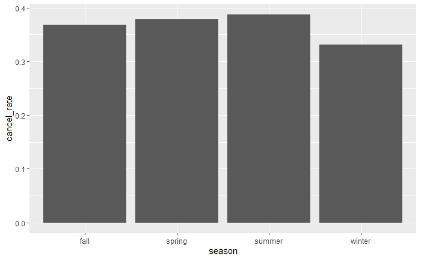

```r
hotels_season %>%
  ggplot() +
  geom_col(aes(x = season, y = cancel_rate))
```

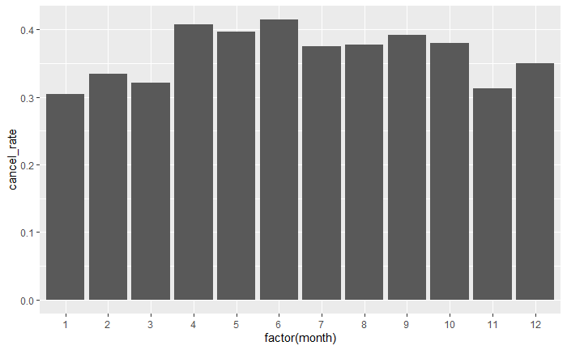

```r
hotels_month %>%
  ggplot() +
  geom_col(aes(x = factor(month), y = cancel_rate))
```

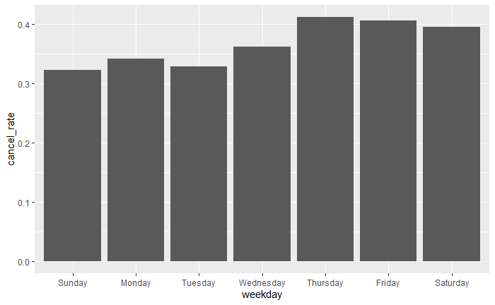

```r
hotels_weekday %>%
  ggplot() +
  geom_col(aes(x = weekday, y = cancel_rate))
```

### Season, month, day of reservation status change

But the day a booking starts is not the only indicator we might be interested in. Indeed, cancellations show even more seasonality when you look at the date the person either checked out or cancelled. This is based on the `reservation_status_date` variable, which is the last date a person’s reservation status was changed. `reservation_status` records whether the person canceled, checked in, or checked out, and the date variable records the date on which this action occurred. Earlier, in the section “Lead time,” I used `reservation_status_date` to derive the number of days before the arrival date a person canceled (cancellation lead time). For more on this variable, see that section.

So, these datasets describe the season, month, and day of the week in which the greatest share of the actions were cancellations (as opposed to check-ins or check-outs). If that sounds confusing, it’s because it is. I’m keeping it here in case I forget how poor it is.

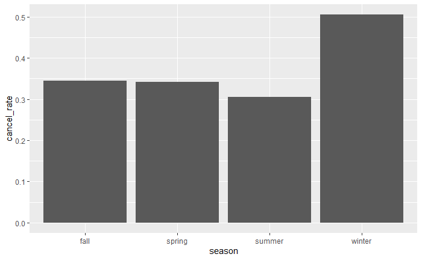

```r
hotels_month <- hotels %>%
  mutate(
    month = month(reservation_status_date)
  ) %>%
  group_by(month) %>%
  summarize(
    n = n(),
    cancel_rate = mean(is_canceled, na.rm = TRUE)
  ) %>%
  ungroup() %>%
  mutate(
    n_sum = sum(n, na.rm = TRUE),
    n_pct = n / n_sum
  )

hotels_season <- hotels %>%
  mutate(
    month = month(reservation_status_date),
    season = case_when(
      month %in% c(1,2,12) ~ 'winter',
      month %in% c(3,4,5) ~ 'spring',
      month %in% c(6,7,8) ~ 'summer',
      month %in% c(9,10,11) ~ 'fall'
    )
  ) %>%
  group_by(season) %>%
  summarize(
    n = n(),
    cancel_rate = mean(is_canceled, na.rm = TRUE)
  ) %>%
  ungroup() %>%
  mutate(
    n_sum = sum(n, na.rm = TRUE),
    n_pct = n / n_sum
  )

hotels_weekday <- hotels %>%
  mutate(
    weekday = lubridate::wday(reservation_status_date, label = TRUE, abbr = FALSE)
  ) %>%
  group_by(weekday) %>%
  summarize(
    n = n(),
    cancel_rate = mean(is_canceled, na.rm = TRUE)
  ) %>%
  ungroup() %>%
  mutate(
    n_sum = sum(n, na.rm = TRUE),
    n_pct = n / n_sum
  )

hotels_season %>%
  ggplot() +
  geom_col(aes(x = season, y = cancel_rate))
```

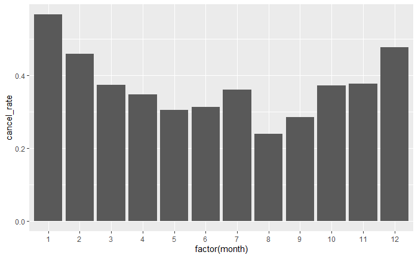

```r
hotels_month %>%
  ggplot() +
  geom_col(aes(x = factor(month), y = cancel_rate))
```

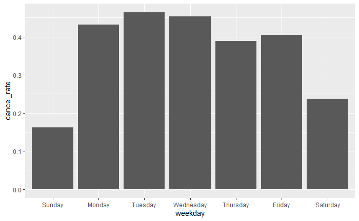

```r
hotels_weekday %>%
  ggplot() +
  geom_col(aes(x = weekday, y = cancel_rate))
```

This is a stark contrast. Most cancellations by far occur in winter, and cancellations are fairly low in the other months. Weekends are ‘safe’ for cancellations, but weekdays are very high risk. This data, though, could be easily misunderstood, and I’ve taken some liberty with the interpretation. Properly, I should say of seasons for example that “for a given season, the odds that any given booking or cancellation was a cancellation increases in winter.” What does that mean? If I consider all of the action that occurred in winter, either someone checking out or someone canceling a reservation, the majority of ‘actions’ were cancellations.

I should change the y-axis title to read “Ratio of checkouts to cancellations in a given season, month, or day of the week.” That would show how absurd this metric is.

A more informative version looks at the distribution of cancellations across the year, and this is what I turn to now. For this, I’ll need yet another set of datasets. One thing to note is that there are more observations for July and August in the whole dataset by design (see section “Distribution Channel and Dates Observed”), so I will only use data from 2016. Otherwise, the means would be unfairly biased towards months with more observations (July and August).

```r
hotels_season <- hotels %>%
  mutate(
    month = month(reservation_status_date),
    season = case_when(
      month %in% c(1,2,12) ~ 'winter',
      month %in% c(3,4,5) ~ 'spring',
      month %in% c(6,7,8) ~ 'summer',
      month %in% c(9,10,11) ~ 'fall'
    )
  ) %>%
  group_by(season) %>%
  filter(is_canceled == 1,
         year(reservation_status_date) == 2016) %>%
  summarize(
    n = n()
  ) %>%
  ungroup() %>%
  mutate(
    n_sum = sum(n, na.rm = TRUE),
    n_pct = n / n_sum,
    test_sum = sum(n_pct)
  )

hotels_month <- hotels %>%
  mutate(
    month = month(reservation_status_date)
  ) %>%
  group_by(month) %>%
  filter(is_canceled == 1,
         year(reservation_status_date) == 2016) %>%
  summarize(
    n = n()
  ) %>%
  ungroup() %>%
  mutate(
    n_sum = sum(n, na.rm = TRUE),
    n_pct = n / n_sum,
    test_sum = sum(n_pct)
  )


hotels_weekday <- hotels %>%
  mutate(
    weekday = lubridate::wday(reservation_status_date, label = TRUE, abbr = FALSE)
  ) %>%
  group_by(weekday) %>%
  filter(is_canceled == 1,
         year(reservation_status_date) == 2016) %>%
  summarize(
    n = n()
  ) %>%
  ungroup() %>%
  mutate(
    n_sum = sum(n, na.rm = TRUE),
    n_pct = n / n_sum,
    test_sum = sum(n_pct)
  )

hotels_season
```

| season | n | n_sum | n_pct | test_sum |
| --- | --- | --- | --- | --- |
| fall | 5141 | 21428 | 0.2399197 | 1 |
| spring | 5422 | 21428 | 0.2530334 | 1 |
| summer | 4102 | 21428 | 0.1914318 | 1 |
| winter | 6763 | 21428 | 0.3156151 | 1 |

```r
hotels_month
```

| month | n | n_sum | n_pct | test_sum |
| --- | --- | --- | --- | --- |
| 1 | 2497 | 21428 | 0.11652977 | 1 |
| 2 | 2161 | 21428 | 0.10084936 | 1 |
| 3 | 2125 | 21428 | 0.09916931 | 1 |
| 4 | 1867 | 21428 | 0.08712899 | 1 |
| 5 | 1430 | 21428 | 0.06673511 | 1 |
| 6 | 1384 | 21428 | 0.06458839 | 1 |
| 7 | 1373 | 21428 | 0.06407504 | 1 |
| 8 | 1345 | 21428 | 0.06276834 | 1 |
| 9 | 1645 | 21428 | 0.07676871 | 1 |
| 10 | 1527 | 21428 | 0.07126190 | 1 |

[output cut: 2 more lines]

```r
hotels_weekday
```

| weekday | n | n_sum | n_pct | test_sum |
| --- | --- | --- | --- | --- |
| Sunday | 1604 | 21428 | 0.07485533 | 1 |
| Monday | 4250 | 21428 | 0.19833862 | 1 |
| Tuesday | 4073 | 21428 | 0.19007840 | 1 |
| Wednesday | 3495 | 21428 | 0.16310435 | 1 |
| Thursday | 2768 | 21428 | 0.12917678 | 1 |
| Friday | 3638 | 21428 | 0.16977786 | 1 |
| Saturday | 1600 | 21428 | 0.07466866 | 1 |

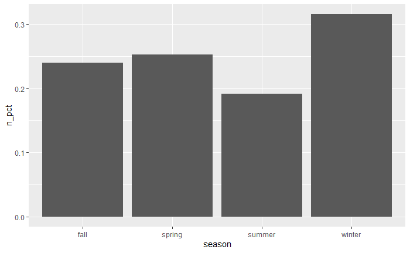

```r
hotels_season %>%
  ggplot() +
  geom_col(aes(x = season, y = n_pct))
```

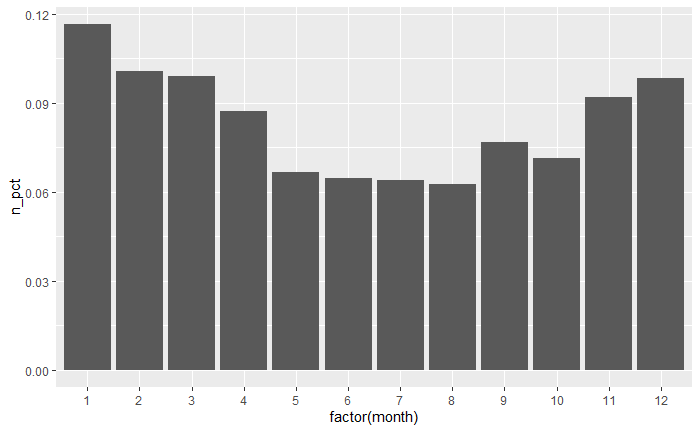

```r
hotels_month %>%
  ggplot() +
  geom_col(aes(x = factor(month), y = n_pct))
```

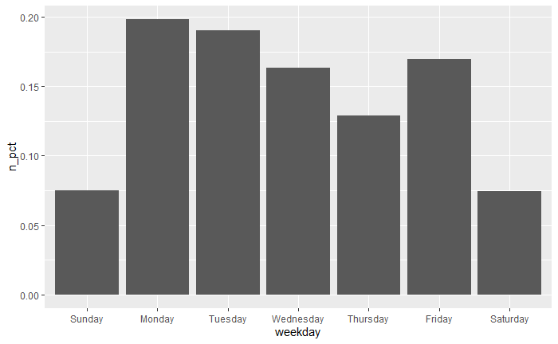

```r
hotels_weekday %>%
  ggplot() +
  geom_col(aes(x = weekday, y = n_pct))
```

This is a much better description of the same idea. The question is simple: When do most cancellations occur? The answer:

- Seasonally, summer sees the fewest cancellations and winter sees the most
- Monthly, following the seasons, January, February, March, and December see the most cancellations. August sees the fewest.
- Weekly, it is rare to cancel on a weekend; it is most common to cancel on a Monday, followed by a Tuesday.

Every season and month has approximately the same number of days in it, so these averages are fairly robust. Some months might have more missing days than others, though, so if you’re so inclined you can make this more robust by calculating the cancellations per day and plotting that. I’m not going to right now, but maybe if I commit to learning more about this particular relationship.

### Average Daily Rate

There could be a relationship between the price a customer pays for a room and the likelihood that they will cancel.

```r
summary(hotels$adr)
```

```
   Min. 1st Qu.  Median    Mean 3rd Qu.    Max.
  -6.38   69.29   94.58  101.83  126.00 5400.00
```

Some reservations are complimentary, according to `market_segment`. These are so few that I’m not worried about them. But still, let’s look at the price breakdown by market segment. The most expensive rooms are booked by online travel agents, followed closely by direct bookings. Corporate bookings seem to get the best rates, as do groups.

| market_segment | mean_adr | median_adr |
| --- | --- | --- |
| Aviation | 100.142110 | 95.0 |
| Complementary | 2.886366 | 0.0 |
| Corporate | 69.358952 | 65.0 |
| Direct | 115.445175 | 105.0 |
| Groups | 79.479472 | 70.0 |
| Offline TA/TO | 87.354783 | 85.5 |
| Online TA | 117.197063 | 109.8 |
| Undefined | 15.000000 | 15.0 |

There is some substantial heterogeneity for the different groups. Let me look at a faceted set of histograms.

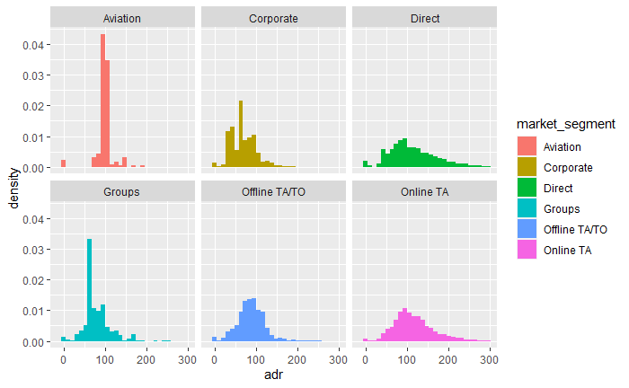

Nearly all complementary stays have a price of zero, so I exclude this group and the undefined group. Looking at the other groups, there are three main patterns. First, airlines are in a class of their own, for their pricing is very consistent. This is probably thanks to agreements between the airline and the hotel as well as airline policies on room quality and cost. Second, the Corporate, Offline TA/TO, and Groups market segments have similar distributions to each other; they tend to be lower and less skewed. Third, the online TA and the direct bookings have approximately the same distribution; they are both centered above 100 and are right skewed.

Nothing here is comparable as is, since many things contribute to costs (especially because there are two separate hotels, which I have deliberately ignored).

To investigate the relationship between price and cancellation behavior, the customer has to be influenced by the costs. This does not, interestingly, rule out complementary stays, but it does rule out corporation and aviation, and possibly groups.

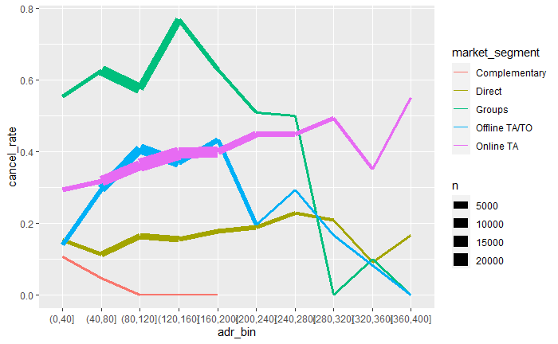

Here, line thickness represents the population of the market segment at that point. Frankly, there are no clear trends. As prices increases, it does seem like cancellations go down, but this is contradicted by an upward trend among those who book with an online travel agent (pink).

## Summary

So far, I’ve looked at the following variables:

- Customer type
- Repeated guests (note: only 3% of guests are repeated guests; data will be sporadic)
- Distribution channel (do bookings through travel agents cancel less often? Does this earn them a discount?)
- Lead time
- Required car parking spaces. (Proxy for something? Maybe only for group size. Probably trash.)
- Total of special requests
- Deposit type (viz. whether a deposit was made)
- Country
- Number of children
- Season, month, day of the week of arrival
- Average daily price

For each, I looked at how it varies with cancellation rates. For some, I spent some time looking closely at the variables and how they relate to other variables in the data set. Particularly long sections were customer_type, distribution_channel and dates observed, deposit_type, country, and “Season, month, day of the week” for both arrival dates and reservation status dates. My findings can be summarized as follows:

One thing you’ll notice about my work so far is that I didn’t distinguish between Hotel A and Hotel B (urban and resort). This was intentional, to reduce the number of cross-sections I had to work with. My work here is nearly done, but if this was an exploratory project, I would follow up on the most interesting variables by looking at their differences across the two hotel types.

# A Final Graphic

What will my final graphic be? What’s most interesting? Perhaps a panel of seasonality characteristics. Either that, or I will make a nicer version of the graph showing lead-time and the likelihood of canceling. The lead time graphic is too thin to make an interesting post, so I would need additional layers to make it worthwhile.

I do like the idea of a collage, though. I would like one central graphic and several side graphics to augment the point. I’ll have to play with the scale to make the numbers all the same size, not sure how I’ll do that without a lot of trial and error. Actually, that could be a difficult part of this. I’ll need to work on my sizes, aspect ratios, and other components of graphic publication, rather than just the information itself.

Seasonality lends itself to this type of analysis. The main graphic could be the distribution of cancellations across the year (monthly) with a sub-graphic for weekly trends and a secondary sub-panel for the seasonality of cancellations by scheduled arrival date. I’m not sure how I could integrate these, but I think it’s interesting that it matters more what season/day it is right this minute than it matters when your reservation was for.

Problems include the biggest one: the data only covers a single year. It’s a sample-size of one, which makes my margin of error huge. It’s helped a little by the large sample size of actual observations, but if this was an abnormal year for any reason, the data has dubious value.